# Initial Analysis of Pedestrian Movement Through Single-Use and Mixed-Use Spaces

### by Finch Brown and JP Lopez

## Introduction

In this project, we will examine the relationship between land use diversity and pedestrian activity using the Seattle Public Life Data: People Moving dataset linked here: (https://data.seattle.gov/Transportation/Public-Life-Data-People-Moving/7rx6-5pgd). The tentative research question we present is: “How does land use diversity impact pedestrian activity in Seattle?” Our group hypothesizes that a higher level of land use diversity will increase pedestrian activity.

## Research Design

To measure land use diversity (explanatory variable), we categorized each location based on the street classifications from the Gehl Institute’s Public Life Data Protocol, which were used in these studies. We classified the 10 categories of streets used in the studies as either single-use or mixed-use areas. We measured pedestrian activity (outcome variable) based on the total counts of moving pedestrians taken for each entry in the dataset. If the data analysis reveals a positive relationship between land use diversity and pedestrian activity, this finding will support our hypothesis, suggesting that diverse land use contributes to more pedestrian movement.

## Exploratory Data Analysis

Our initial analysis visually shows a positive relationship between mixed-used areas and more pedestrians moving through the space, with a statistically significant p-value. We had some issues with data visualizations and will continue to work on cleaning the data and interpreting summary statistics in the final report.

```r
library(tidyverse)
# loading data
people_moving_df <- read.csv("Public_Life.csv")

locations_df <- read.csv("locations.csv")

unique(locations_df$location_character)
```

```
## [1] "Commercial"      "Mixed"           "Infrastructural" "CBD"
## [5] "Residential"     "Medical"         "Recreational"    "Civic"
```

```r
# isolating important rows
small_loc_df <- data.frame(locations_df$location_id, locations_df$location_line_typology_vehicular)

small_move_df <- data.frame(people_moving_df$unique_moving_id,  people_moving_df$moving_row_total, people_moving_df$moving_time_start, people_moving_df$moving_time_end, people_moving_df$location_id)

# changing column names
colnames(small_loc_df) <- c("location", "typology")

colnames(small_move_df) <- c("id", "total_count", "start", "end", "location")

# combining dataframes
new_df <- left_join(small_loc_df, small_move_df,
                             by = join_by(location),
                             multiple = "all")

# creating column to categorize neighborhood types

unique(new_df$typology)
```

```
##  [1] "Neighborhood Corridor"             "Urban Village Neighborhood"
##  [3] "Urban Village Neighborhood Access" "Downtown Neighborhood"
##  [5] "Downtown Neighborhood Access"      "Downtown"
##  [7] "Urban Center Connector"            "Urban Village Main"
##  [9] "Neighborhood Yield Street"         "Industrial Access"
```

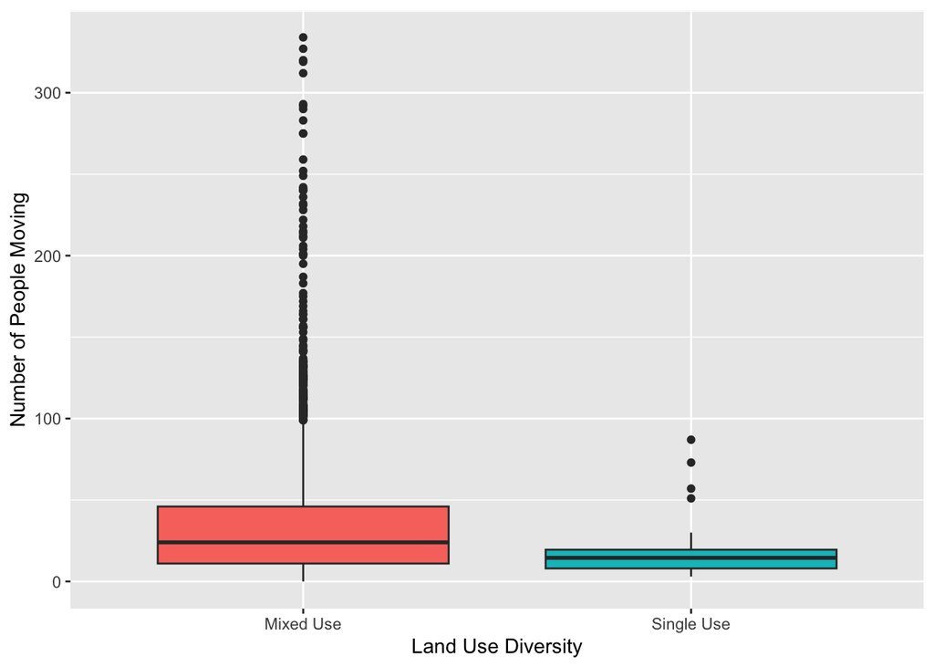

```r
new_df$classification <- ifelse(new_df$typology %in% c("Neighborhood Corridor", "Urban Village Neighborhood Access", "Urban Village Neighborhood", "Downtown Neighborhood", "Downtown", "Downtown Neighborhood Access", "Urban Center Connector", "Urban Village Main"), 1, 0)

# creating column for count per unit of time

new_df$start <- as.POSIXlt(new_df$start, format="%d/%m/%Y %I:%M:%S %p", tz = "UTC", na.rm = T)

new_df$end <- as.POSIXlt(new_df$end, format="%d/%m/%Y %I:%M:%S %p", tz = "UTC", na.rm = T)

new_df$duration <- as.numeric((new_df$end - new_df$start) / 60)

new_df$count_per_minute <- new_df$total_count / new_df$duration

# making a boxplot

new_df$land_use <- ifelse(new_df$classification == 1, "Mixed Use", "Single Use")

boxplot <- ggplot(new_df, aes(x = land_use,
                          y = total_count,
                          fill = land_use), na.rm = TRUE) +
  geom_boxplot() +
  xlab("Land Use Diversity") +
  ylab ("Number of People Moving") +
  theme(legend.position = "none")
boxplot
```

```r
# making a scatterplot
# plot(new_df$land_use, df$total_count, na.rm = T,
 #     xlab = "Land Use",
 #    ylab = "Pedestrians Through the Space",
 #    col = ifelse(new_df$land_use == 1, "green", "purple"))

# conducting main regression

model <- lm(total_count ~ classification, data = new_df)

summary(model)
```

```
##
## Call:
## lm(formula = total_count ~ classification, data = new_df)
##
## Residuals:
##     Min      1Q  Median      3Q     Max
## -36.379 -25.379 -11.379   9.621 297.621
##
## Coefficients:
##                Estimate Std. Error t value Pr(>|t|)
## (Intercept)      19.531      7.207   2.710  0.00678 **
## classification   16.848      7.256   2.322  0.02032 *
## ---
## Signif. codes:  0 '***' 0.001 '**' 0.01 '*' 0.05 '.' 0.1 ' ' 1
##
## Residual standard error: 40.77 on 2376 degrees of freedom
##   (4 observations deleted due to missingness)
## Multiple R-squared:  0.002264,   Adjusted R-squared:  0.001844
## F-statistic: 5.391 on 1 and 2376 DF,  p-value: 0.02032
```

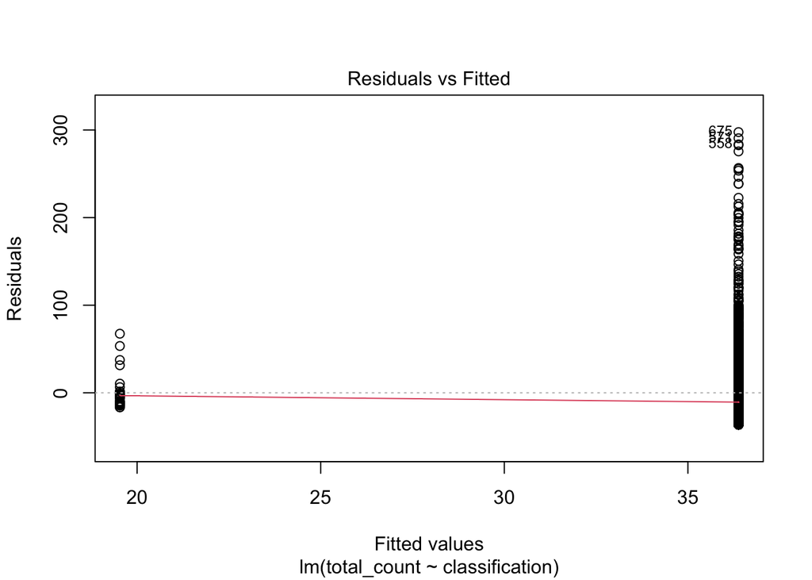

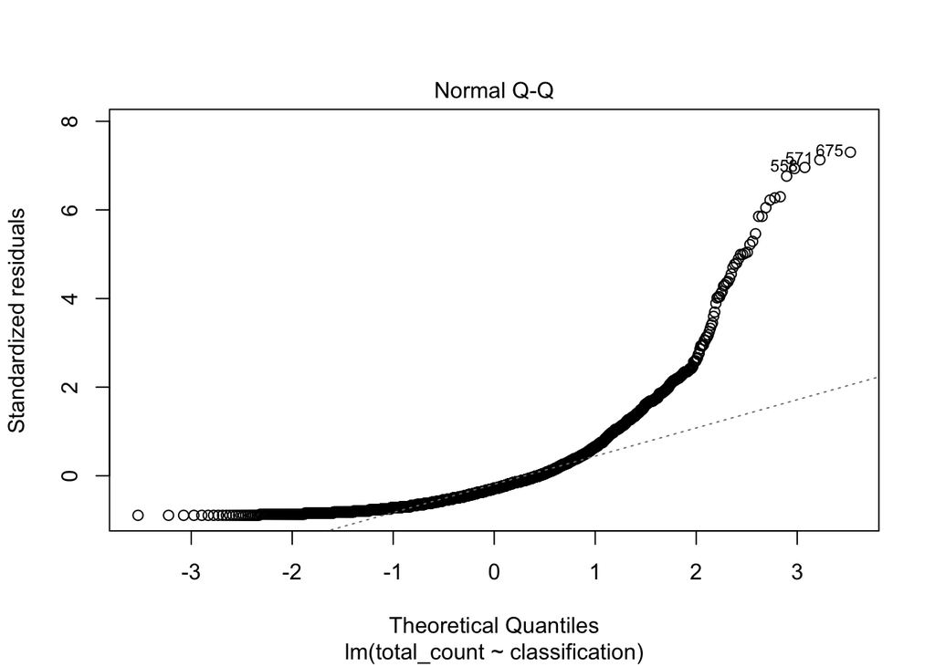

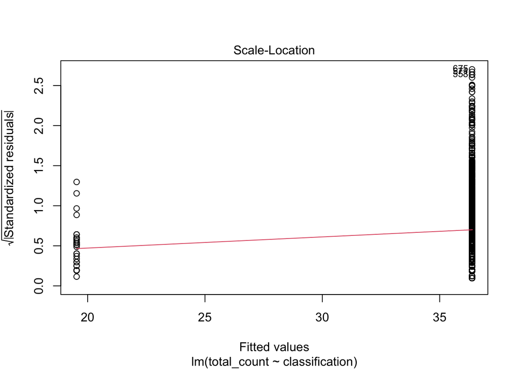

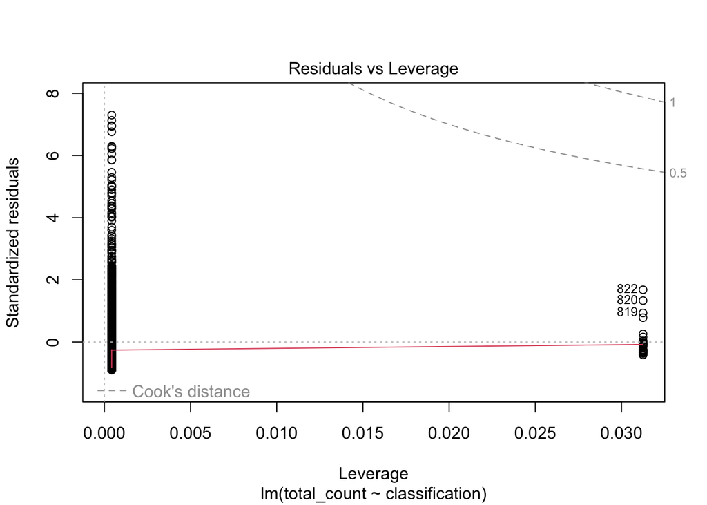

```r
plot(model)
```